# Part A, Topic 1 - COVID-19

Lance Belen

2 June 2025

# Data Wrangling and Integration

First, load the packages needed.

```r
options(repos = c(CRAN = "https://cloud.r-project.org/"))

if (!requireNamespace("tidyverse", quietly = TRUE)) {
  install.packages("tidyverse")
}
if (!requireNamespace("lubridate", quietly = TRUE)) {
  install.packages("lubridate")
}
if (!requireNamespace("impute", quietly = TRUE)) {
  install.packages("impute")
}
if (!requireNamespace("dplyr", quietly = TRUE)) {
  install.packages("dplyr")
}
if (!requireNamespace("magrittr", quietly = TRUE)) {
  install.packages("magrittr")
}
if (!requireNamespace("ggplot2", quietly = TRUE)) {
  install.packages("ggplot2")
}
if (!requireNamespace("readxl", quietly = TRUE)) {
  install.packages("readxl")
}
if (!requireNamespace("stringr", quietly = TRUE)) {
  install.packages("stringr")
}
if (!requireNamespace("forcats", quietly = TRUE)) {
  install.packages("forcats")
}
if (!requireNamespace("tidytext", quietly = TRUE)) {
  install.packages("tidytext")
}

if (!requireNamespace("caret", quietly = TRUE)) {
  install.packages("caret")
}

library(tidyverse)
library(lubridate)
library(impute)
library(dplyr)
library(magrittr)
library(ggplot2)
library(readxl)
library(stringr)
library(forcats)
library(tidytext)
library(caret)
```

Then, read and open the three datasets, Covid-data.csv, CountryLockdowndates.csv and WorldwideVaccineData.csv

```r
covid <- read.csv("Covid-data.csv")
lockdown <- read.csv("CountryLockdowndates.csv")
vaccine <- read.csv("WorldwideVaccineData.csv")
```

## Exploration

**Covid-data.csv**

```r
cat("Number of rows:", nrow(covid), "\n")
cat("Number of columns:", ncol(covid), "\n")
cat("Number of missing values:", sum(is.na(covid)), "\n")
knitr::kable(head(covid), caption = "First 6 rows of the dataset")
cat("Structure of the dataset:\n")
str(covid)
cat("Summary of the dataset:\n")
summary(covid)
```

```
## Number of rows: 1575
```

```
## Number of columns: 8
```

```
## Number of missing values: 13
```

First 6 rows of the dataset

| location | date | total_cases | new_cases | total_deaths | new_deaths | gdp_per_capita | population |
| --- | --- | --- | --- | --- | --- | --- | --- |
| Australia | 2019-12-31 | 0 | 0 | 0 | 0 | 44648.71 | 25499881 |
| Australia | 2020-01-01 | 0 | 0 | 0 | 0 | 44648.71 | 25499881 |
| Australia | 2020-01-02 | 0 | 0 | 0 | 0 | 44648.71 | 25499881 |
| Australia | 2020-01-03 | 0 | 0 | 0 | 0 | 44648.71 | 25499881 |
| Australia | 2020-01-04 | 0 | 0 | 0 | 0 | 44648.71 | 25499881 |
| Australia | 2020-01-05 | 0 | 0 | 0 | 0 | 44648.71 | 25499881 |

```
## Structure of the dataset:
```

```
## 'data.frame':    1575 obs. of  8 variables:
##  $ location      : chr  "Australia" "Australia" "Australia" "Australia" ...
##  $ date          : chr  "2019-12-31" "2020-01-01" "2020-01-02" "2020-01-03" ...
##  $ total_cases   : int  0 0 0 0 0 0 0 0 0 0 ...
##  $ new_cases     : int  0 0 0 0 0 0 0 0 0 0 ...
##  $ total_deaths  : int  0 0 0 0 0 0 0 0 0 0 ...
##  $ new_deaths    : int  0 0 0 0 0 0 0 0 0 0 ...
##  $ gdp_per_capita: num  44649 44649 44649 44649 44649 ...
##  $ population    : int  25499881 25499881 25499881 25499881 25499881 25499881 25499881 25499881 25499881 25499881 ...
```

```
## Summary of the dataset:
```

```
##    location             date            total_cases          new_cases
##  Length:1575        Length:1575        Min.   :      0.0   Min.   :-29726
##  Class :character   Class :character   1st Qu.:     21.5   1st Qu.:     1
##  Mode  :character   Mode  :character   Median :  58226.0   Median :   205
##                                        Mean   : 180451.9   Mean   :  2971
##                                        3rd Qu.: 173133.0   3rd Qu.:  1880
##                                        Max.   :3363056.0   Max.   : 66625
##
##   total_deaths      new_deaths      gdp_per_capita    population
##  Min.   :     0   Min.   :-1918.0   Min.   :15309   Min.   :2.550e+07
##  1st Qu.:     0   1st Qu.:    0.0   1st Qu.:26677   1st Qu.:6.046e+07
##  Median :  2837   Median :    5.0   Median :38606   Median :6.789e+07
##  Mean   : 14060   Mean   :  183.8   Mean   :35140   Mean   :2.652e+08
##  3rd Qu.: 25100   3rd Qu.:  149.0   3rd Qu.:42201   3rd Qu.:2.075e+08
##  Max.   :135605   Max.   : 4928.0   Max.   :54225   Max.   :1.439e+09
##  NA's   :6        NA's   :7
```

**CountryLockdowndates.csv**

```r
cat("Number of rows:", nrow(lockdown), "\n")
cat("Number of columns:", ncol(lockdown), "\n")
cat("Number of missing values:", sum(is.na(lockdown)), "\n")
knitr::kable(head(lockdown), caption = "First 6 rows of the dataset")
cat("Structure of the dataset:\n")
str(lockdown)
cat("Summary of the dataset:\n")
summary(lockdown)
```

```
## Number of rows: 307
```

```
## Number of columns: 5
```

```
## Number of missing values: 0
```

First 6 rows of the dataset

| Country.Region | Province | Date | Type | Reference |
| --- | --- | --- | --- | --- |
| Afghanistan |  | 24/03/2020 | Full | https://www.thestatesman.com/world/afghan-govt-imposes-lockdown-coronavirus-cases-increase-15-1502870945.html |
| Albania |  | 08/03/2020 | Full | https://en.wikipedia.org/wiki/2020_coronavirus_pandemic_in_Albania |
| Algeria |  | 24/03/2020 | Full | https://www.garda.com/crisis24/news-alerts/325896/algeria-government-implements-lockdown-and-curfew-in-blida-and-algiers-march-23-update-7 |
| Andorra |  | 16/03/2020 | Full | https://en.wikipedia.org/wiki/2020_coronavirus_pandemic_in_Andorra |
| Angola |  | 24/03/2020 | Full | https://en.wikipedia.org/wiki/2020_coronavirus_pandemic_in_Angola |
| Antigua and Barbuda |  |  | None |  |

```
## Structure of the dataset:
```

```
## 'data.frame':    307 obs. of  5 variables:
##  $ Country.Region: chr  "Afghanistan" "Albania" "Algeria" "Andorra" ...
##  $ Province      : chr  "" "" "" "" ...
##  $ Date          : chr  "24/03/2020" "08/03/2020" "24/03/2020" "16/03/2020" ...
##  $ Type          : chr  "Full" "Full" "Full" "Full" ...
##  $ Reference     : chr  "https://www.thestatesman.com/world/afghan-govt-imposes-lockdown-coronavirus-cases-increase-15-1502870945.html" "https://en.wikipedia.org/wiki/2020_coronavirus_pandemic_in_Albania" "https://www.garda.com/crisis24/news-alerts/325896/algeria-government-implements-lockdown-an…
```

```
## Summary of the dataset:
```

```
##  Country.Region       Province             Date               Type
##  Length:307         Length:307         Length:307         Length:307
##  Class :character   Class :character   Class :character   Class :character
##  Mode  :character   Mode  :character   Mode  :character   Mode  :character
##   Reference
##  Length:307
##  Class :character
##  Mode  :character
```

**WorldwideVaccineData.csv**

```r
cat("Number of rows:", nrow(vaccine), "\n")
cat("Number of columns:", ncol(vaccine), "\n")
cat("Number of missing values:", sum(is.na(vaccine)), "\n")
knitr::kable(head(vaccine), caption = "First 6 rows of the dataset")
cat("Structure of the dataset:\n")
str(vaccine)
summary(vaccine)
```

```
## Number of rows: 187
```

```
## Number of columns: 5
```

```
## Number of missing values: 0
```

First 6 rows of the dataset

| Country | Doses.administered.per.100.people | Total.doses.administered | X..of.population.vaccinated | X..of.population.fully.vaccinated |
| --- | --- | --- | --- | --- |
| Afghanistan | 17 | 6445359 | 15 | 13 |
| Albania | 102 | 2906126 | 46 | 44 |
| Algeria | 35 | 15205854 | 19 | 16 |
| Angola | 64 | 20397115 | 41 | 22 |
| Argentina | 237 | 106474858 | 92 | 84 |
| Armenia | 73 | 2150112 | 38 | 33 |

```
## Structure of the dataset:
```

```
## 'data.frame':    187 obs. of  5 variables:
##  $ Country                          : chr  "Afghanistan" "Albania" "Algeria" "Angola" ...
##  $ Doses.administered.per.100.people: int  17 102 35 64 237 73 162 229 207 137 ...
##  $ Total.doses.administered         : num  6.45e+06 2.91e+06 1.52e+07 2.04e+07 1.06e+08 ...
##  $ X..of.population.vaccinated      : num  15 46 19 41 92 38 84 88 77 53 ...
##  $ X..of.population.fully.vaccinated: num  13 44 16 22 84 33 78 86 75 48 ...
```

```
##    Country          Doses.administered.per.100.people Total.doses.administered
##  Length:187         Min.   :  0                       Min.   :1.714e+04
##  Class :character   1st Qu.: 62                       1st Qu.:1.810e+06
##  Mode  :character   Median :130                       Median :8.179e+06
##                     Mean   :131                       Mean   :6.493e+07
##                     3rd Qu.:199                       3rd Qu.:2.865e+07
##                     Max.   :343                       Max.   :3.408e+09
##  X..of.population.vaccinated X..of.population.fully.vaccinated
##  Min.   : 0.10               Min.   : 0.10
##  1st Qu.:36.50               1st Qu.:29.00
##  Median :62.00               Median :55.00
##  Mean   :56.91               Mean   :51.94
##  3rd Qu.:80.00               3rd Qu.:75.00
##  Max.   :99.00               Max.   :99.00
```

## Wrangling

I have chosen to use KNN imputation to deal with missing values or wrong values such as negative values for new cases, deaths, vaccinated, etc. From the exploration above, only covid has missing values, so I will impute that dataset using K Nearest Neighbors (KNN). By using KNN, I can fill in the missing values based on the values of the nearest neighbors in the dataset, allowing us keep the rest of the data for those entries.

```r
library(impute)
library(dplyr)
library(magrittr)

cat("Number of missing values before imputation:", sum(is.na(covid)), "\n")

covid_imputed <- covid %>%
  select(where(is.numeric)) %>%
  as.matrix() %>%
  impute.knn(k = 5) %>%
  .$data %>%
  as.data.frame()

covid[, colnames(covid_imputed)] <- covid_imputed

cat("Number of missing values after imputation:", sum(is.na(covid)), "\n")
```

```
## Number of missing values before imputation: 13
```

```
## Cluster size 1575 broken into 1378 197
## Done cluster 1378
## Done cluster 197
```

```
## Number of missing values after imputation: 0
```

I also want to remove any negative values from the dataset as they are not valid in some of the available features. First, check if there are indeed any entries that have such values.

**Covid-data.csv**

```
##   total_cases new_cases total_deaths new_deaths gdp_per_capita population
## 1       FALSE      TRUE        FALSE       TRUE          FALSE      FALSE
```

In this case, new_cases and new_deaths are the only columns that have negative values, but those values are not valid. I will remove any rows that have negative values in those columns.

```r
cat("Number of rows before removing negative values:", nrow(covid), "\n")
covid <- covid %>%
  filter(new_cases >= 0 & new_deaths >= 0)
cat("Number of rows after removing negative values:", nrow(covid), "\n")
```

```
## Number of rows before removing negative values: 1575
```

```
## Number of rows after removing negative values: 1568
```

Since CountryLockdowndates.csv doesn’t have numerical values, I will now proceed to WorldwideVaccineData.csv.

**WorldwideVaccineData.csv**

```
##   Doses.administered.per.100.people Total.doses.administered
## 1                             FALSE                    FALSE
##   X..of.population.vaccinated X..of.population.fully.vaccinated
## 1                       FALSE                             FALSE
```

With this, I can confirm that there are no negative values in this dataset, so no further action is needed.

## Integration

Now that I have cleaned the datasets, we can integrate them into one. Firstly, the date attributes are in different formats for Covid-data.csv and CountryLockdowndates.csv, so I need to convert them to the same format.

```r
covid$date <- as.Date(covid$date, format = "%Y-%m-%d")
lockdown$Date <- as.Date(lockdown$Date, format = "%d/%m/%Y")

cat("Covid-data.csv date format: ", class(covid$date), "\nHead: ", head(covid$date))
cat("CountryLockdowndates.csv date format: ", class(lockdown$Date), "\nHead: ", head(lockdown$Date))
```

```
## Covid-data.csv date format:  Date
## Head:  18261 18262 18263 18264 18265 18266
```

```
## CountryLockdowndates.csv date format:  Date
## Head:  18345 18329 18345 18337 18345 NA
```

Next, I will rename the columns in the datasets as per the requirements of the merged dataset. The expected columns are: - location - date - total_cases - new_cases - total_deaths - new_deaths - gdp_per_capita - population - lockdown_date - total doses administered - % of population fully vaccinated

```r
lockdown <- lockdown %>%
  rename(location = Country.Region,
         lockdown_date = Date)
vaccine <- vaccine %>%
  rename(location = Country,
         `total doses administered` = `Total.doses.administered`,
         `% of population fully vaccinated` = `X..of.population.fully.vaccinated`)
```

```r
data <- covid %>%
  left_join(lockdown %>% select(location, lockdown_date), by = "location") %>%
  left_join(vaccine %>% select(location, `total doses administered`, `% of population fully vaccinated`), by = "location")
```

```r
cat("Number of rows:", nrow(data), "\n")
cat("Number of columns:", ncol(data), "\n")
cat("Number of missing values:", sum(is.na(covid %>% select(where(is.numeric)))), "\n")
knitr::kable(head(data), caption = "First 6 rows of the merged dataset")
cat("Structure of the merged dataset:\n")
str(data)
cat("Summary of the merged dataset:\n")
summary(data)
```

```
## Number of rows: 12303
```

```
## Number of columns: 11
```

```
## Number of missing values: 0
```

First 6 rows of the merged dataset

| location | date | total_cases | new_cases | total_deaths | new_deaths | gdp_per_capita | population | lockdown_date | total doses administered | % of population fully vaccinated |
| --- | --- | --- | --- | --- | --- | --- | --- | --- | --- | --- |
| Australia | 2019-12-31 | 0 | 0 | 0 | 0 | 44648.71 | 25499881 | NA | 57988175 | 86 |
| Australia | 2019-12-31 | 0 | 0 | 0 | 0 | 44648.71 | 25499881 | NA | 57988175 | 86 |
| Australia | 2019-12-31 | 0 | 0 | 0 | 0 | 44648.71 | 25499881 | NA | 57988175 | 86 |
| Australia | 2019-12-31 | 0 | 0 | 0 | 0 | 44648.71 | 25499881 | NA | 57988175 | 86 |
| Australia | 2019-12-31 | 0 | 0 | 0 | 0 | 44648.71 | 25499881 | NA | 57988175 | 86 |
| Australia | 2019-12-31 | 0 | 0 | 0 | 0 | 44648.71 | 25499881 | NA | 57988175 | 86 |

```
## Structure of the merged dataset:
```

```
## 'data.frame':    12303 obs. of  11 variables:
##  $ location                        : chr  "Australia" "Australia" "Australia" "Australia" ...
##  $ date                            : Date, format: "2019-12-31" "2019-12-31" ...
##  $ total_cases                     : num  0 0 0 0 0 0 0 0 0 0 ...
##  $ new_cases                       : num  0 0 0 0 0 0 0 0 0 0 ...
##  $ total_deaths                    : num  0 0 0 0 0 0 0 0 0 0 ...
##  $ new_deaths                      : num  0 0 0 0 0 0 0 0 0 0 ...
##  $ gdp_per_capita                  : num  44649 44649 44649 44649 44649 ...
##  $ population                      : num  25499881 25499881 25499881 25499881 25499881 ...
##  $ lockdown_date                   : Date, format: NA NA ...
##  $ total doses administered        : num  5.8e+07 5.8e+07 5.8e+07 5.8e+07 5.8e+07 ...
##  $ % of population fully vaccinated: num  86 86 86 86 86 86 86 86 86 86 ...
```

```
## Summary of the merged dataset:
```

```
##    location              date             total_cases        new_cases
##  Length:12303       Min.   :2019-12-31   Min.   :      0   Min.   :    0.0
##  Class :character   1st Qu.:2020-02-17   1st Qu.:    882   1st Qu.:    4.0
##  Mode  :character   Median :2020-04-06   Median :  80932   Median :   43.0
##                     Mean   :2020-04-05   Mean   :  80965   Mean   :  920.1
##                     3rd Qu.:2020-05-25   3rd Qu.:  84378   3rd Qu.:  545.0
##                     Max.   :2020-07-14   Max.   :3363056   Max.   :66625.0
##                     NA's   :1189
##   total_deaths      new_deaths      gdp_per_capita    population
##  Min.   :     0   Min.   :   0.00   Min.   :15309   Min.   :2.550e+07
##  1st Qu.:    17   1st Qu.:   0.00   1st Qu.:15309   1st Qu.:6.527e+07
##  Median :  3241   Median :   1.00   Median :15309   Median :1.439e+09
##  Mean   :  7304   Mean   :  85.11   Mean   :27512   Mean   :7.624e+08
##  3rd Qu.:  4639   3rd Qu.:  37.00   3rd Qu.:39753   3rd Qu.:1.439e+09
##  Max.   :135605   Max.   :4928.00   Max.   :54225   Max.   :1.439e+09
##
##  lockdown_date        total doses administered % of population fully vaccinated
##  Min.   :2020-01-23   Min.   : 57988175        Min.   :67.00
##  1st Qu.:2020-01-23   1st Qu.: 57988175        1st Qu.:79.00
##  Median :2020-01-23   Median :146731437        Median :79.00
##  Mean   :2020-02-08   Mean   :131644832        Mean   :80.97
##  3rd Qu.:2020-03-14   3rd Qu.:146731437        3rd Qu.:86.00
##  Max.   :2020-03-27   Max.   :597655035        Max.   :86.00
##  NA's   :3840         NA's   :8078             NA's   :8078
```

```r
unique(data$location)
```

```
##  [1] "Australia"      "Australia  "    "China"          " China"
##  [5] "France"         "Iran"           "iran"           "Italy"
##  [9] "Itly"           "Spain"          "United Kingdom" "UnitedKingdom"
## [13] "United States"  "United Stats"
```

I can see that some of the values in the location column are not consistent, so I will need to clean them up accordingly.

```r
data$location <- data$location %>%
  str_replace_all("iran", "Iran") %>%
  str_replace_all("Itly", "Italy") %>%
  str_replace_all("UnitedKingdom", "United Kingdom") %>%
  str_replace_all("United Stats", "United States") %>%
  str_trim()
```

After cleaning up:

```r
unique(data$location)
```

```
## [1] "Australia"      "China"          "France"         "Iran"
## [5] "Italy"          "Spain"          "United Kingdom" "United States"
```

# Data Visualisation and Analysis

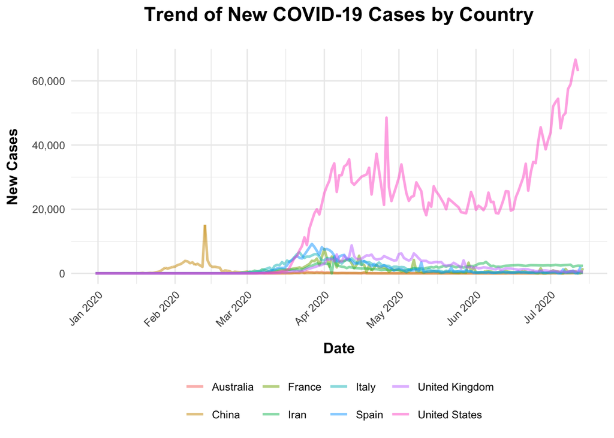

```r
library(scales)

data %>%
  filter(!is.na(new_cases), !is.na(date), !is.na(location)) %>%
  ggplot(aes(x = date, y = new_cases, color = location)) +
  geom_line(size = 1, alpha = 0.5) +
  labs(title = "Trend of New COVID-19 Cases by Country", x = "Date", y = "New Cases") +
  scale_x_date(date_labels = "%b %Y", date_breaks = "1 month") +
  theme_minimal() +
  theme(
    legend.position = "bottom", legend.title = element_blank(),
    axis.text.x = element_text(angle = 45, hjust = 1),
    axis.title.x = element_text(size = 12, face = "bold", margin = margin(t = 10)),
    axis.title.y = element_text(size = 12, face = "bold", margin = margin(r = 10)),
    plot.title = element_text(size = 16, face = "bold", hjust = 0.5, margin = margin(b = 20)),
  ) +
  scale_y_continuous(labels = comma)
```

The first occurrence of a notable observation of new cases is in China, which reflects the fact that it is the origin of the novel coronavirus outbreak, also known as COVID-19 (Centers for Disease Control and Prevention (2024)). A significant increase can also be seen in the United States, compared to other countries in the dataset, which started after about a month since China’s spike. This event forced a declaration in the United States for a nationwide emergency and further overseas travel bans on the 13th of March, 2020. (Centers for Disease Control and Prevention (2024)). By August 2020, the reported total number of cases in U.S.A. was 5.04 million, which is evident of the prolonged large number of new cases daily as seen in the plot (Bergquist et al. (2020)).

Apart from the two significant findings previously mentioned, it can also be seen that the trend of the number of new cases are similar among the European countries. By February 2020, the virus has reached Europe, with Italy being the first to react with lockdowns in different provinces as cases began to rise. By April 2020, numerous countries in Europe have reached 10,000 total cases, which is also evident in the plot (Chadwick (2020))

The observed shift in the increase of new cases from China to other countries supports the fact that the outbreak originated in China. As international travel occurs daily, the spread of the virus to other places was inevitable, which explains the gradual and fluctuating rise in cases. Because of this, numerous countries implemented lockdowns and travel bans to control the spread of the virus, leading to a slow decline in new cases, which became more apparent by the middle to late part of 2020 in most countries.

Now here is an observation of the relationship between the death rate and new case numbers with the GDP of each country.

```r
mean_gdp <- data %>%
  summarise(mean_gdp = mean(gdp_per_capita, na.rm = TRUE)) %>%
  pull(mean_gdp)
cat("Mean GDP: ", mean_gdp, "\n")
```

```
## Mean GDP:  27512.46
```

```r
data <- data %>%
  mutate(GDP_Status = ifelse(gdp_per_capita >= mean_gdp, 1, 0))

cat("Number of rows with GDP Status 1: ", nrow(data[data$GDP_Status == 1, ]), "\n")
cat("Number of rows with GDP Status 0: ", nrow(data[data$GDP_Status == 0, ]), "\n")
```

[output not shown]

[output not shown]

```r
data <- data %>%
  mutate(new_case_rate = new_cases / population,
         new_death_rate = new_deaths / population)

head(data %>% filter(new_case_rate > 0 & new_death_rate > 0), 10)
```

```
##     location       date total_cases new_cases total_deaths new_deaths
## 1  Australia 2020-03-01          26         1            1          1
## 2  Australia 2020-03-01          26         1            1          1
## 3  Australia 2020-03-01          26         1            1          1
## 4  Australia 2020-03-01          26         1            1          1
## 5  Australia 2020-03-01          26         1            1          1
## 6  Australia 2020-03-01          26         1            1          1
## 7  Australia 2020-03-01          26         1            1          1
## 8  Australia 2020-03-01          26         1            1          1
## 9  Australia 2020-03-05          52        11            2          1
## 10 Australia 2020-03-05          52        11            2          1
##    gdp_per_capita population lockdown_date total doses administered
## 1        44648.71   25499881          <NA>                 57988175
## 2        44648.71   25499881          <NA>                 57988175
## 3        44648.71   25499881          <NA>                 57988175
```

[output cut: 18 more lines]

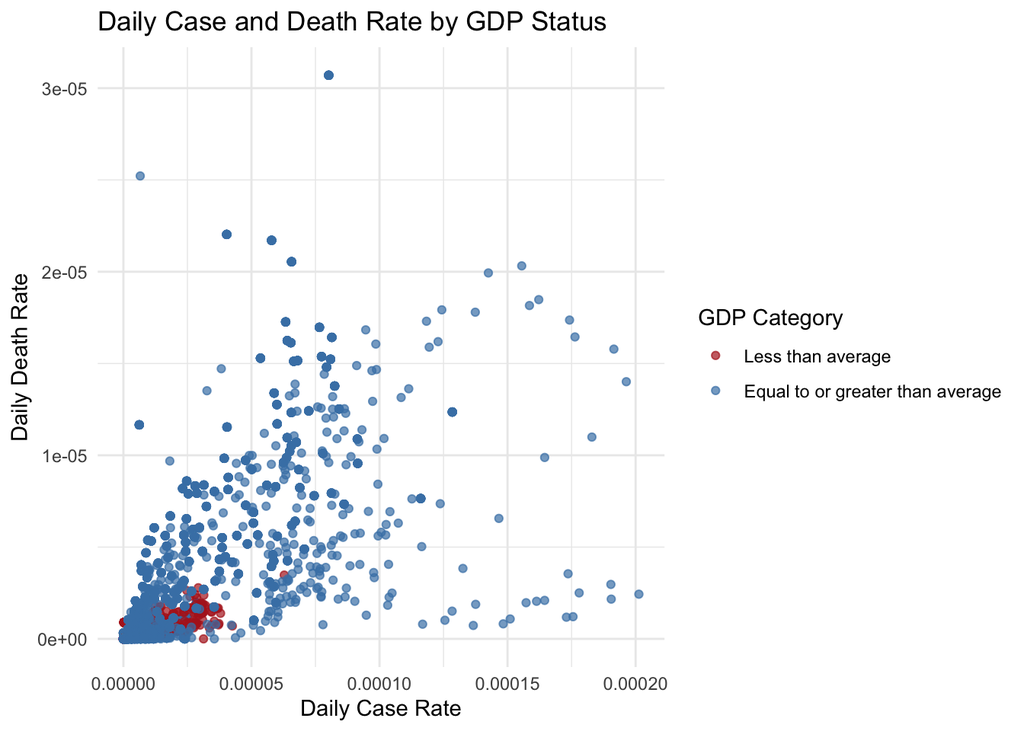

```r
ggplot(data, aes(x = new_case_rate, y = new_death_rate, color = factor(GDP_Status))) +
  geom_point(alpha = 0.7) +
  scale_color_manual(
    values = c("0" = "firebrick", "1" = "steelblue"),
    labels = c("0" = "Less than average", "1" = "Equal to or greater than average"),
    name = "GDP Category"
  ) +
  labs(
    title = "Daily Case and Death Rate by GDP Status",
    x = "Daily Case Rate",
    y = "Daily Death Rate"
  ) +
  theme_minimal()
```

The Gross Domestic Product, or GDP, is a representation of the monetary value of goods and services produced by a country in a specified period. (Callen (2025)) If this value is to be divided by the total population of a country, we would get the GDP per capita, which is the number that we have in our dataset that represents a rough measure of a country’s living standards, or simply, the financial capability of a person in the country.

From the scatter plot above, it can be seen that countries with lower than average GDP per capita tend to have lower daily new/death case rates. This can be due to multiple factors such as the country lacking the capability to have robust healthcare and data systems, leading to underreporting of the number of new cases and deaths per day. It can also be linked to factors such as the life expectancy and tourist spending being significantly lower than those that have average or greater GDP per capita. To provide an example:

- Luxembourg is identified as having the highest GDP per capita. Burundi is identified as having the lowest estimated GDP per capita. (The World Factbook (2025)).
- Life expectancy in Luxembourg is 82.8 years. Burundi’s is 64 years. Almost 20 years difference (World Health Organisation, 2023).
- Luxembourg tourist spending for 2017 was 5.47 billion US Dollars (macrotrends (2025)). Burundi tourist spending for 2017 was 0.1 billion US dollars. (Knoema Data Appliance (2025)).

Overseas travel played a major role in the global spread of COVID-19 as rapid transmission across borders occurred. In 2020, the death rate from the virus for those that are aged 85 and over was 1,645 per 100,000 population – seven times greater than the rate for those aged 65 to 74. (Tejada-Vera et al. (2022)).

# Predictive Data Analaysis

Firstly, let’s create the model so we can plot a polynomial regression line. I will start with using the number of days since the earliest date in the dataset as the predictor variable for the number of new cases. For the training and testing sets, I will split the data into 70% for training and 30% for testing.

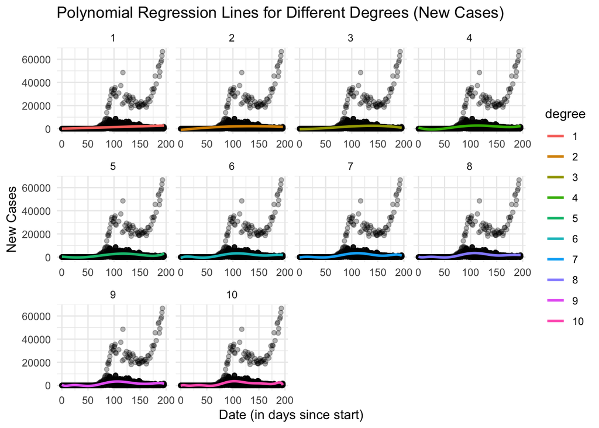

```r
data_higher_gdp <- data %>%
  filter(GDP_Status == 1, !is.na(new_cases), !is.na(date)) %>%
  mutate(date_num = as.numeric(as.Date(date) - min(as.Date(date))))

# Split train/test sets
set.seed(4)
train_indices <- sample(1:nrow(data_higher_gdp), size = 0.7 * nrow(data_higher_gdp))
train <- data_higher_gdp[train_indices, ]
test <- data_higher_gdp[-train_indices, ]

# Create a sequence of dates for smooth prediction lines
date_seq <- seq(min(train$date_num), max(train$date_num), length.out = 100)

# Initialize a dataframe to store predictions for all models
all_preds <- data.frame()

for (deg in 1:10) {
  # Fit the model with current degree for date
  model <- lm(new_cases ~ poly(date_num, deg), data = train)

  # Predict on the date sequence with fixed GDP per capita
  pred_df <- data.frame(date_num = date_seq)
  pred_df$new_cases <- predict(model, newdata = pred_df)
  pred_df$degree <- factor(deg)

  all_preds <- bind_rows(all_preds, pred_df)
}

# Plot all polynomial lines in a facet grid
ggplot() +
  geom_point(data = train, aes(x = date_num, y = new_cases), alpha = 0.3) +
  geom_line(data = all_preds, aes(x = date_num, y = new_cases, color = degree), size = 1) +
  facet_wrap(~ degree, scales = "free_x") +
  labs(
    title = "Polynomial Regression Lines for Different Degrees (New Cases)",
    x = "Date (in days since start)",
    y = "New Cases"
  ) +
  theme_minimal()
```

Next, I will use the total number of cases as the predictor variable.

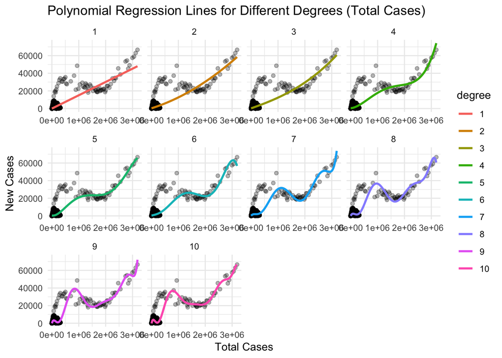

```r
# Model to predict new cases based on total cases
all_preds <- data.frame()  # initialize outside the loop

for (deg in 1:10) {
  model <- lm(new_cases ~ poly(total_cases, deg), data = train)

  pred_df <- data.frame(total_cases = seq(min(train$total_cases), max(train$total_cases), length.out = 100))
  pred_df$new_cases <- predict(model, newdata = pred_df)
  pred_df$degree <- factor(deg)

  all_preds <- bind_rows(all_preds, pred_df)
}

ggplot() +
  geom_point(data = train, aes(x = total_cases, y = new_cases), alpha = 0.3) +
  geom_line(data = all_preds, aes(x = total_cases, y = new_cases, color = degree), size = 1) +
  facet_wrap(~ degree, scales = "free_x") +
  labs(
    title = "Polynomial Regression Lines for Different Degrees (Total Cases)",
    x = "Total Cases",
    y = "New Cases"
  ) +
  theme_minimal()
```

From these plots, I can see that degree 7 seems to be the best fit for the polynomial regression line, as it captures the trend of the new cases based on the total cases without overfitting.

Next, I want to check what other variables can be used to predict the new cases. The three variables below are the ones that might have an effect on the number of new cases. I will check the number of unique values in each of these variables to see if they are suitable for polynomial regression.

```
## number of unique locations in the dataset:  6
```

```
## number of unique population values in the dataset:  6
```

```
## number of unique GDP per capita values in the dataset:  6
```

There are six unique locations, unique population values and unique GDP per capita values in the dataset. Six different locations might be a good number to use as a predictor variable. Six unique population values most likely isn’t enough to use as a predictor variable, given that the population value is numerical. Similarly, six unique GDP per capita values is also not enough to use as a predictor variable.

I will now use the location as a predictor variable for the new cases.

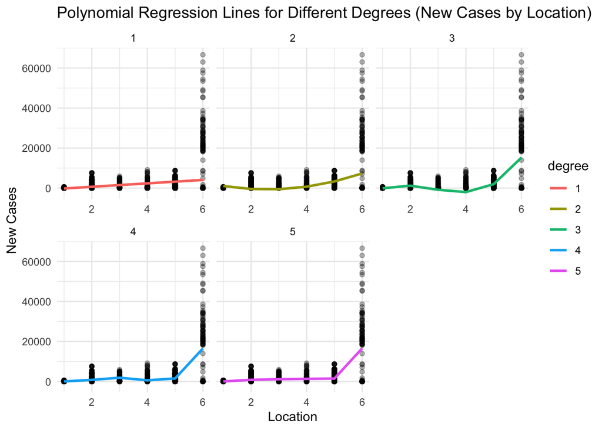

```r
# Convert location to a factor
data_higher_gdp$location <- as.factor(data_higher_gdp$location)
train$location <- as.factor(train$location)
test$location <- as.factor(test$location)

# Create a sequence of locations for smooth prediction lines
location_seq <- levels(data_higher_gdp$location)

# Initialize a dataframe to store predictions for all models
all_preds <- data.frame()

for (deg in 1:5) {
  # Fit the model with current degree for location
  model <- lm(new_cases ~ poly(as.numeric(location), deg), data = train)

  # Predict on the location sequence
  pred_df <- data.frame(location = seq_along(location_seq))
  pred_df$new_cases <- predict(model, newdata = pred_df)
  pred_df$degree <- factor(deg)

  all_preds <- bind_rows(all_preds, pred_df)
}

# Plot all polynomial lines in a facet grid
ggplot() +
  geom_point(data = train, aes(x = as.numeric(location), y = new_cases), alpha = 0.3) +
  geom_line(data = all_preds, aes(x = as.numeric(location), y = new_cases, color = degree), size = 1) +
  facet_wrap(~ degree, scales = "free_x") +
  labs(
    title = "Polynomial Regression Lines for Different Degrees (New Cases by Location)",
    x = "Location",
    y = "New Cases"
  ) +
  theme_minimal()
```

```r
# Print what the encoded locations are
location_encoded <- data.frame(
  Location = levels(data_higher_gdp$location),
  Encoding = seq_along(levels(data_higher_gdp$location))
)

print(location_encoded)
```

```
##         Location Encoding
## 1      Australia        1
## 2         France        2
## 3          Italy        3
## 4          Spain        4
## 5 United Kingdom        5
## 6  United States        6
```

From these plots, I will chose degree 1 (linear) as it captures the trend of the new cases based on the location without overfitting.

Finally, I will now create a model to predict new cases based on the three predictor variables that I have used and the degrees that are best suited for each of them. I understand that my choices for the degrees are subjective to models with only the corresponding predcitor variable above. Hence, I will loop through the degrees 5, 6, and 7 for the date_num and total_cases predictor variables to see how the line fits the data.

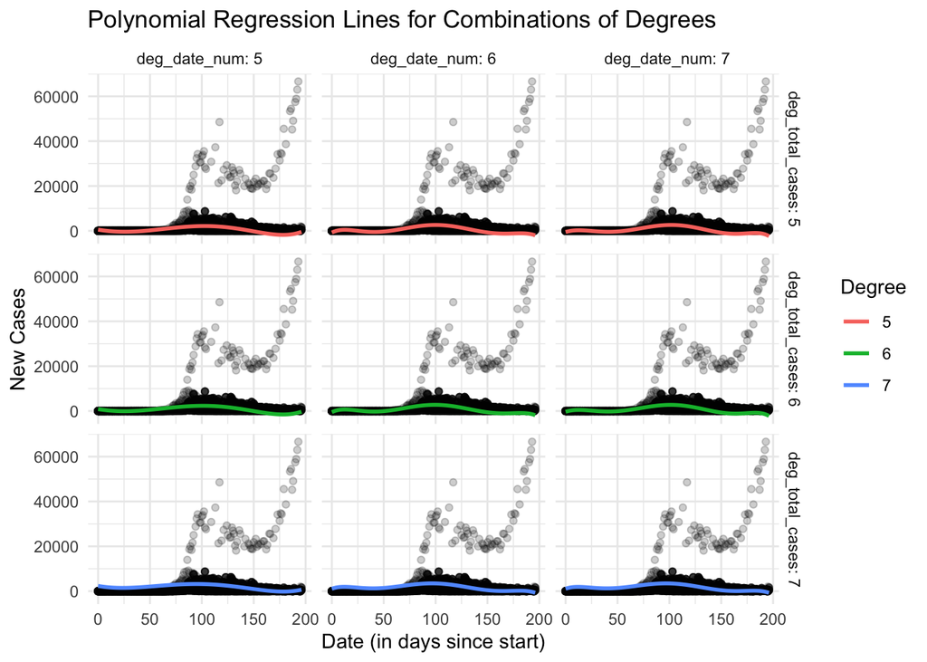

```r
# Define the degree combinations for poly(date_num, deg1) and poly(total_cases, deg2)
deg_combinations <- expand.grid(deg_date = 5:7, deg_cases = 5:7)

# Create prediction dataframe with 100 points
date_seq <- seq(min(train$date_num), max(train$date_num), length.out = 100)
mean_total_cases <- mean(train$total_cases, na.rm = TRUE)
fixed_location <- factor(levels(train$location)[1], levels = levels(train$location))

# Container to store all prediction results
all_preds <- data.frame()

# Loop over all combinations of degrees
for (i in 1:nrow(deg_combinations)) {
  deg_date <- deg_combinations$deg_date[i]
  deg_cases <- deg_combinations$deg_cases[i]

  # Fit model
  model <- lm(new_cases ~ poly(date_num, deg_date) + poly(total_cases, deg_cases) + location, data = train)

  # Create prediction dataframe
  pred_df <- data.frame(
    date_num = date_seq,
    total_cases = mean_total_cases,
    location = fixed_location
  )

  # Predict new cases
  pred_df$new_cases <- predict(model, newdata = pred_df)
  pred_df$deg_date_num <- factor(deg_date)
  pred_df$deg_total_cases <- factor(deg_cases)

  all_preds <- bind_rows(all_preds, pred_df)
}

# Plot: Facet grid of regression lines
ggplot() +
  geom_point(data = train, aes(x = date_num, y = new_cases), alpha = 0.2) +
  geom_line(data = all_preds, aes(x = date_num, y = new_cases, color = deg_total_cases), size = 1) +
  facet_grid(deg_total_cases ~ deg_date_num, labeller = label_both) +
  labs(
    title = "Polynomial Regression Lines for Combinations of Degrees",
    x = "Date (in days since start)",
    y = "New Cases",
    color = "Degree"
  ) +
  theme_minimal()
```

Here’s the plot for the final model for a better visualisation of the polynomial regression line.

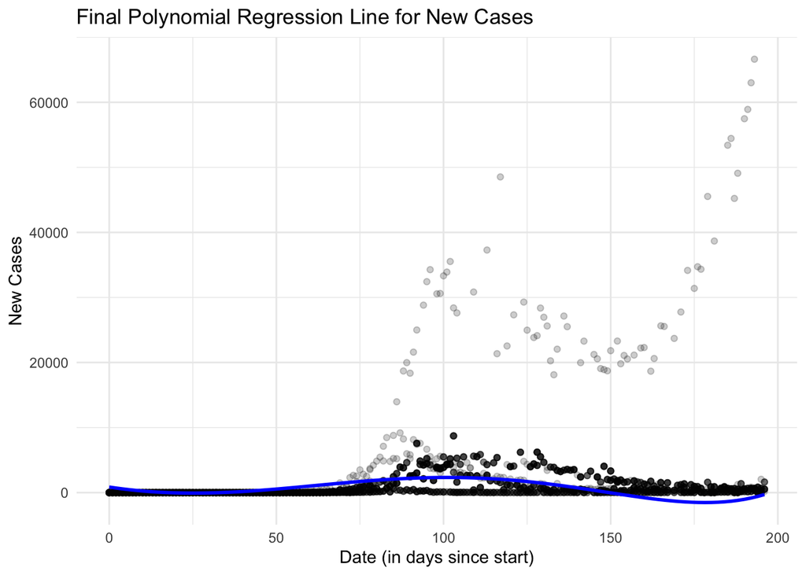

```r
# Final model with chosen degrees
final_model <- lm(new_cases ~ poly(date_num, 5) + poly(total_cases, 6) + location, data = train)

# Create prediction dataframe
pred_df <- data.frame(
  date_num = date_seq,
  total_cases = mean_total_cases,
  location = fixed_location
)

# Predict new cases
pred_df$new_cases <- predict(final_model, newdata = pred_df)

# Plot the final model
ggplot() +
  geom_point(data = train, aes(x = date_num, y = new_cases), alpha = 0.2) +
  geom_line(data = pred_df, aes(x = date_num, y = new_cases), color = "blue", size = 1) +
  labs(
    title = "Final Polynomial Regression Line for New Cases",
    x = "Date (in days since start)",
    y = "New Cases"
  ) +
  theme_minimal()
```

### Predictions on the newly infected case numbers

Now I will use the model to make a prediction on the new cases for the last five to seven days in the dataset. This is so I can compare the predicted values with the actual values in the dataset. I will use the test dataset first, then evaluate using K-fold Cross Validation.

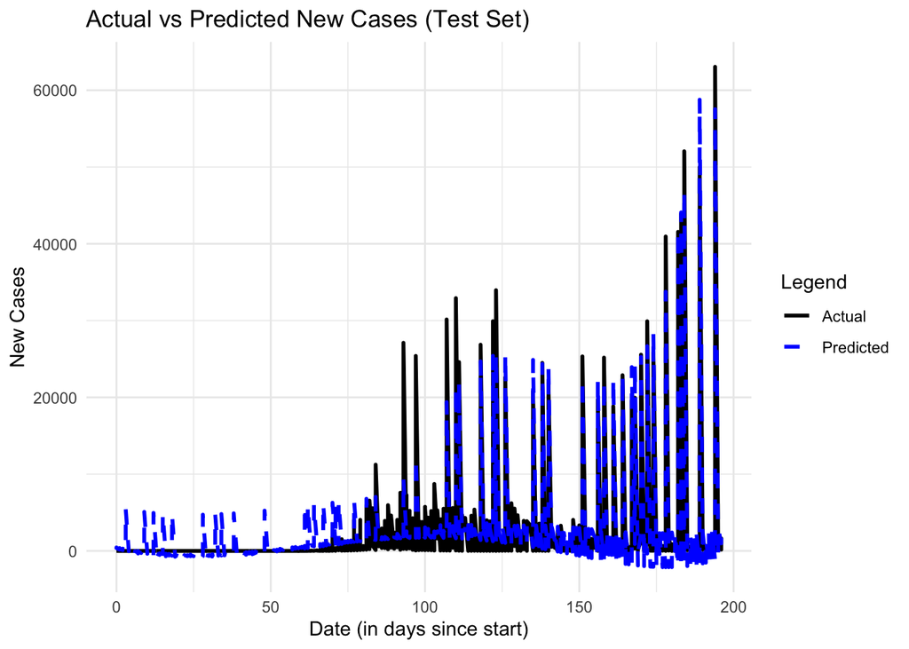

```r
# Create a prediction dataframe from the test set
pred_test_df <- data.frame(
  date_num = test$date_num,
  total_cases = test$total_cases,
  location = test$location
)

# Predict new cases using the final model
pred_test_df$predicted_new_cases <- predict(final_model, newdata = pred_test_df)

# Combine with actual test data for comparison
test_combined <- test %>%
  select(date_num, location, new_cases) %>%
  mutate(predicted_new_cases = pred_test_df$predicted_new_cases)

# Plot: Actual vs Predicted New Cases on Test Set
ggplot(test_combined, aes(x = date_num)) +
  geom_line(aes(y = new_cases, color = "Actual"), size = 1) +
  geom_line(aes(y = predicted_new_cases, color = "Predicted"), size = 1, linetype = "dashed") +
  labs(
    title = "Actual vs Predicted New Cases (Test Set)",
    x = "Date (in days since start)",
    y = "New Cases",
    color = "Legend"
  ) +
  scale_color_manual(values = c("Actual" = "black", "Predicted" = "blue")) +
  theme_minimal()
```

```r
# Get the last 7 unique days in date_num
last_days <- sort(unique(test_combined$date_num), decreasing = TRUE)[1:7]

# Filter test_combined for only those days
last_week_predictions <- test_combined %>%
  filter(date_num %in% last_days) %>%
  arrange(date_num, location)

# Rename columns for clarity
last_week_predictions <- last_week_predictions %>%
  select(date_num, location, new_cases, predicted_new_cases) %>%
  rename(
    Days_Since_Start_Date = date_num,
    Location = location,
    Actual = new_cases,
    Predicted = predicted_new_cases
  )

# Print the results
print(last_week_predictions)
```

```
##    Days_Since_Start_Date       Location Actual  Predicted
## 1                    190      Australia    169 -1622.9947
## 2                    190      Australia    169 -1622.9947
## 3                    190      Australia    169 -1622.9947
## 4                    190      Australia    169 -1622.9947
## 5                    190         France    475   190.0016
## 6                    190         France    475   190.0016
## 7                    190         France    475   190.0016
## 8                    190         France    475   190.0016
## 9                    190 United Kingdom    581  2360.9782
## 10                   190 United Kingdom    581  2360.9782
## 11                   190 United Kingdom    581  2360.9782
## 12                   191      Australia    131 -1526.3437
## 13                   191      Australia    131 -1526.3437
## 14                   191         France    663   296.8814
```

[output cut: 46 more lines]

To show how the model performs, I will calculate the Root Mean Squared Error (RMSE) and R-squared values for the predictions.

```r
# Calculate RMSE and R-squared
rmse <- sqrt(mean((test_combined$predicted_new_cases - test_combined$new_cases)^2))
r_squared <- 1 - (sum((test_combined$predicted_new_cases - test_combined$new_cases)^2) / sum((test_combined$new_cases - mean(test_combined$new_cases))^2))
cat("RMSE: ", rmse, "\n")
cat("R-squared: ", r_squared, "\n")
```

```
## RMSE:  1599.545
```

```
## R-squared:  0.866855
```

To furthe validate the model, I will apply K-fold Cross-Validation to evaluate the predictions.

```r
set.seed(4)

# Create a control object for K-fold cross-validation
train_control <- trainControl(method = "cv", number = 5)

# Fit the model using K-fold cross-validation
cv_model <- train(
  new_cases ~ poly(date_num, 5) + poly(total_cases, 6) + location,
  data = data_higher_gdp,
  method = "lm",
  trControl = train_control
)

# Print the results of the cross-validation
print(cv_model)
```

```
## Linear Regression
##
## 5332 samples
##    3 predictor
##
## No pre-processing
## Resampling: Cross-Validated (5 fold)
## Summary of sample sizes: 4266, 4264, 4266, 4266, 4266
## Resampling results:
##
##   RMSE      Rsquared   MAE
##   1782.621  0.8297452  1065.72
##
## Tuning parameter 'intercept' was held constant at a value of TRUE
```

Before applying K-fold Cross Validation, the model achieved an R-squared of 0.87 and an RMSE of 1599.55, indicating a strong fit to the testing data with realtively lower prediction error. However, after evaluating the model using K-fold Cross Validation, the R-squared decreased slightly to 0.83 and RMSE increased to 1782.62, indicating that the model may be overfitting as it performs well on testing data but struggles to generalise. The presence of outliers in the dataset may have contributed to this discrepancy, as they can disproportionately affect the model’s performance, leading to higher RMSE and lower R-squared values during cross-validation. Applying K-fold Cross Validation helps to mitigate this issue by providing a more robust evaluation of the model’s performance across different subsets of the data. However, in this instance, the model’s performance on unseen data is not as strong as it was on the testing data.

To further enhance the model’s performance and generalisation capabilities, steps such as outlier handling and feature selection may be necessary. Although the sudden spikes in COVID-19 new cases might appear as outliers from a statistical perspective, they could present legitimate events such as outbreaks or changes in reporting practices. Therefore, while outright removal of these points may not be appropriate, techniques like robust regression or transformations could be used to reducte the impact without disregarding meaningful data. Moreover, applying feature selection helps lessen the noise from irrelevant or redundant features, allowing the model to focus on the most significant predictors. In this context, simply adding more data may not yield better performance especially if the underlying patterns remain volatile. Thus, refining the quality of the input data and ensuring the model does not overly rely on extreme values are more practical approaches to improve the model’s predictive capabilities.

# References

Bergquist, S., Otten, T., & Sarich, N. (2020). COVID-19 pandemic in the united states. *Health Policy and Technology*, *9*(4), 623–638. https://doi.org/10.1016/j.hlpt.2020.08.007

Callen, T. (2025). *Gross domestic product: An economy’s all*. https://www.imf.org/en/Publications/fandd/issues/Series/Back-to-Basics/gross-domestic-product-GDP

Centers for Disease Control and Prevention. (2024). *CDC museum COVID-19 timeline*. https://www.cdc.gov/museum/timeline/covid19.html

Chadwick, L. (2020). *How COVID-19 upended life in europe throughout 2020*. https://www.euronews.com/2020/12/31/how-covid-19-upended-life-in-europe-throughout-2020

Knoema Data Appliance. (2025). *Burundi - leisure travel and tourism spending in current prices*. https://opendataforafrica.org/atlas/Burundi/topics/Tourism/Leisure-Travel-and-Tourism-Spending/Leisure-travel-and-tourism-spending

macrotrends. (2025). *Luxembourg tourism statistics 2002-2025*. https://www.macrotrends.net/global-metrics/countries/lux/luxembourg/tourism-statistics

Tejada-Vera, B., S., M., & Kramarow, E. A. (2022). *COVID-19 mortality in adults aged 65 and over: United states, 2020*. https://www.cdc.gov/nchs/products/databriefs/db446.htm

The World Factbook. (2025). *Real GDP per capita*. http://cia.gov/the-world-factbook/field/real-gdp-per-capita/country-comparison/